Applied Statistics with R (STAT 215) Tutorial 1: The R Language Ziling Ma ziling.ma@kaust.edu.sa September 29, 2024

# 1 Assigning Objects

1. Create an object that stores the value $32 × \frac{41}{8}$.

**Click for answer**

```r
a <- 32 * 41 / 8
print(a)
```

```
## [1] 164
```

```r
# or you can simply use 'a'
```

2. Overwrite your object in (a) by itself divided by $2.33$. Print the result to the console.

**Click for answer**

```r
# Notice here we would like to overwrite
a <- a / 2.33
# check value of a
a
```

```
## [1] 70.38627
```

3. Create a new object with the value $−8.2 × 10^{−3}$.

**Click for answer**

```r
b <- -8.2 * 10^(-3)
```

4. Print directly to the console the result of multiplying (b) by (c).

**Click for answer**

```r
(a * b)
```

```
## [1] -0.5771674
```

Back to top

# 2 Vectors

1. Create and store a sequence of values from 5 to −11 that progresses in steps of 0.3.

**Click for answer**

```r
sq <- seq(5,-11,by=-0.3)
sq
```

```
##  [1]   5.0   4.7   4.4   4.1   3.8   3.5   3.2   2.9   2.6   2.3   2.0   1.7
## [13]   1.4   1.1   0.8   0.5   0.2  -0.1  -0.4  -0.7  -1.0  -1.3  -1.6  -1.9
## [25]  -2.2  -2.5  -2.8  -3.1  -3.4  -3.7  -4.0  -4.3  -4.6  -4.9  -5.2  -5.5
## [37]  -5.8  -6.1  -6.4  -6.7  -7.0  -7.3  -7.6  -7.9  -8.2  -8.5  -8.8  -9.1
## [49]  -9.4  -9.7 -10.0 -10.3 -10.6 -10.9
```

2. Overwrite the object from (a) using the same sequence with the order reversed.

**Click for answer**

```r
sq <- rev(sq)
sq
```

```
##  [1] -10.9 -10.6 -10.3 -10.0  -9.7  -9.4  -9.1  -8.8  -8.5  -8.2  -7.9  -7.6
## [13]  -7.3  -7.0  -6.7  -6.4  -6.1  -5.8  -5.5  -5.2  -4.9  -4.6  -4.3  -4.0
## [25]  -3.7  -3.4  -3.1  -2.8  -2.5  -2.2  -1.9  -1.6  -1.3  -1.0  -0.7  -0.4
## [37]  -0.1   0.2   0.5   0.8   1.1   1.4   1.7   2.0   2.3   2.6   2.9   3.2
## [49]   3.5   3.8   4.1   4.4   4.7   5.0
```

3. Repeat the vector c(-1,3,-5,7,-9) twice, with each element repeated 10 times, and store the result. Display the result sorted from largest to smallest.

**Click for answer**

```r
# Create the vector
vec <- c(-1, 3, -5, 7, -9)

# Repeat the vector twice, with each element repeated 10 times
repeated_vec <- rep(vec, each = 10, times = 2)

# Sort the result from largest to smallest
sorted_vec <- sort(repeated_vec, decreasing = TRUE)

# Print the sorted result
sorted_vec
```

```
##   [1]  7  7  7  7  7  7  7  7  7  7  7  7  7  7  7  7  7  7  7  7  3  3  3  3  3
##  [26]  3  3  3  3  3  3  3  3  3  3  3  3  3  3  3 -1 -1 -1 -1 -1 -1 -1 -1 -1 -1
##  [51] -1 -1 -1 -1 -1 -1 -1 -1 -1 -1 -5 -5 -5 -5 -5 -5 -5 -5 -5 -5 -5 -5 -5 -5 -5
##  [76] -5 -5 -5 -5 -5 -9 -9 -9 -9 -9 -9 -9 -9 -9 -9 -9 -9 -9 -9 -9 -9 -9 -9 -9 -9
```

4. Extract the first and last elements of your vector from (b), storing them as a new object.

**Click for answer**

```r
# We name the vector 'sq'

# Extract the first element of 'sq', notice in R (also in Matlab), we start from 1 instead of 0 like in Python
sq[1]
```

```
## [1] -10.9
```

```r
# Extract the last element, same as in Python you use -1, in Matlab you use 'end'
sq[length(sq)]
```

```
## [1] 5
```

Back to top

# 3 Matrix operations

In `R`, use just one line of code to create the following mtrices and assign them to the variables `W`, and `X`, respectively.
$$W=\begin{pmatrix}
1 & 4 & 7 \\
2 & 5 & 8 \\
3 & 6 & 9
\end{pmatrix};
X = \begin{pmatrix}
1 & 2 & 3 \\
4 & 5 & 6 \\
7 & 8 & 9
\end{pmatrix};$$

**Click for answer**

```r
(W <- matrix(data = 1:9, nrow = 3, ncol = 3, byrow = FALSE))
```

```
##      [,1] [,2] [,3]
## [1,]    1    4    7
## [2,]    2    5    8
## [3,]    3    6    9
```

```r
(X <- matrix(data = 1:9, nrow = 3, ncol = 3, byrow = TRUE))
```

```
##      [,1] [,2] [,3]
## [1,]    1    2    3
## [2,]    4    5    6
## [3,]    7    8    9
```

Also, compute $W\odot X$ and $W\cdot X$, such that $\odot$ represents the element-wise multiplication and $\cdot$ represents matrix multiplication.

**Click for answer**

```r
W * X
```

```
##      [,1] [,2] [,3]
## [1,]    1    8   21
## [2,]    8   25   48
## [3,]   21   48   81
```

```r
W %*% X
```

```
##      [,1] [,2] [,3]
## [1,]   66   78   90
## [2,]   78   93  108
## [3,]   90  108  126
```

Given a matrix Y, where

```r
 Y <- matrix(c(2,3,1,4),nrow = 2)
 Y
```

```
##      [,1] [,2]
## [1,]    2    1
## [2,]    3    4
```

How can you compute the inverse matrix of Y?

**Click for answer**

```r
solve(Y)
```

```
##      [,1] [,2]
## [1,]  0.8 -0.2
## [2,] -0.6  0.4
```

Back to top

# 4 Matrix and functions

Create a matrix $A\in\mathbb R^{3\times3}$, such that
$$a_{ij} = i + j,\quad\forall i,j.$$

**Click for answer**

```r
A <- matrix(nrow = 3, ncol = 3)
for(i in 1:3) {
  for(j in 1:3) {
    A[i,j] <- i + j
  }
}
A
```

```
##      [,1] [,2] [,3]
## [1,]    2    3    4
## [2,]    3    4    5
## [3,]    4    5    6
```

Also, create $B\in \mathbb R^{3\times3}$, such that
$$b_{ij}=\begin{cases}
\text{TRUE}, & a_{ij} \text{ is even}, \\
\text{FALSE}, &\text{otherwise}.
\end{cases}$$

**Click for answer**

```r
fB <- function(b) return(!as.logical(b %% 2))
(B <- matrix(fB(A), nrow = 3, ncol = 3))
```

```
##       [,1]  [,2]  [,3]
## [1,]  TRUE FALSE  TRUE
## [2,] FALSE  TRUE FALSE
## [3,]  TRUE FALSE  TRUE
```

3. Create $C\in \mathbb R^{3\times3}$, such that
   $$c_{ij}=\begin{cases}
   1, & a_{ij} \in \{1,2,3\}, \\
   0, &\text{otherwise}.
   \end{cases}$$

**Click for answer**

```r
fC <- function(c) return(as.numeric(c %in% c(1,2,3)))
(C <- apply(A, MARGIN = c(1,2), fC))
```

```
##      [,1] [,2] [,3]
## [1,]    1    1    0
## [2,]    1    0    0
## [3,]    0    0    0
```

4. Confirm the dimensions of the matrix from (a) are $2 × 3$ if you remove any one row.

**Click for answer**

```r
A_modified <- A[-1, ]
A_modified
```

```
##      [,1] [,2] [,3]
## [1,]    3    4    5
## [2,]    4    5    6
```

```r
dim(A_modified)
```

```
## [1] 2 3
```

Back to top

# 5 Recursive functions 1

Write a function for computing $f(n)=n!,\ (n\in \mathbb N)$. Print the 10 first numbers from the sequence $f$. Also, for $n=10$, compare your result with the `gamma()` function from `R` (recall that, for any positive integer $n$, $\Gamma(n) = (n-1)!$).

**Click for answer**

```r
factorial <- function(n){
  if((n == 0) || (n == 1))
    return(1)
  else
    return (n * factorial(n-1))
}
sapply(0:9, FUN = factorial)
```

```
##  [1]      1      1      2      6     24    120    720   5040  40320 362880
```

```r
cat("Gamma(10) =", gamma(10), "; 9! =", factorial(9))
```

```
## Gamma(10) = 362880 ; 9! = 362880
```

Back to top

# 6 Graph function

Use the functions `outer` y `persp` to graph the following functions“)
$$f(x, y) = 1 -
exp(-1 / (x^2 + y^2)), \text{for}\: x, y ∈ [-5, 5]$$
$$f(x, y) = sin(x)cos(y), \text{for}\: x, y ∈
[-\pi/2, \pi/2]$$

**Click for answer**

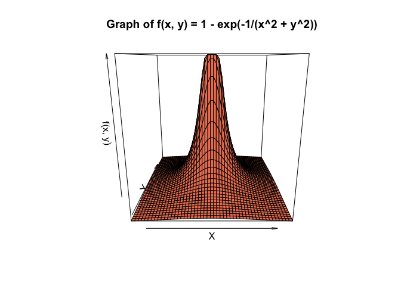

```r
# Define the range for x and y
x <- seq(-5, 5, length = 50)
y <- seq(-5, 5, length = 50)

# Define the function
f1 <- function(x, y) {
  1 - exp(-1 / (x^2 + y^2))
}

# Create a grid using outer
z1 <- outer(x, y, f1)

# Plot using persp
persp(x, y, z1, col = "salmon2",
      xlab = "X", ylab = "Y", zlab = "f(x, y)",
      main = "Graph of f(x, y) = 1 - exp(-1/(x^2 + y^2))")
```

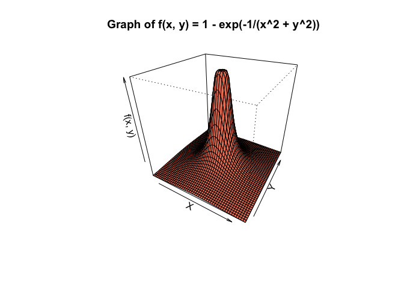

```r
# Notice, you can adjust the theta and phi values in persp() if you want a different viewing angle, for example
persp(x, y, z1, theta = 30, phi = 30,col = "salmon2",
      xlab = "X", ylab = "Y", zlab = "f(x, y)",
      main = "Graph of f(x, y) = 1 - exp(-1/(x^2 + y^2))")
```

**Click for answer**

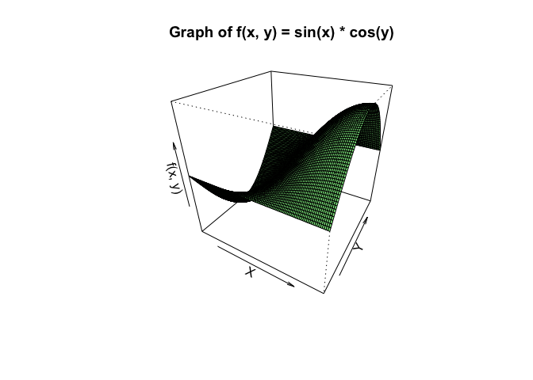

```r
# Define the range for x and y
x2 <- seq(-pi/2, pi/2, length = 100)
y2 <- seq(-pi/2, pi/2, length = 100)

# Define the function
f2 <- function(x, y) {
  sin(x) * cos(y)
}

# Create a grid using outer
z2 <- outer(x2, y2, f2)

# Plot using persp
persp(x2, y2, z2, theta = 30, phi = 30, col = "lightgreen",
      xlab = "X", ylab = "Y", zlab = "f(x, y)",
      main = "Graph of f(x, y) = sin(x) * cos(y)")
```

Back to top

# 7 Linear regression

Suppose that we model the height of male teenagers as
$$\mathrm{height}_i = \beta_0 + \beta_1 \cdot \mathrm{age}_i +
\epsilon_i,\ \text{s.t. } \epsilon_i \sim \mathcal N\left(0,
\sigma^2\right).$$
Now, for a random sample of size $n=20$, we want to estimate $\boldsymbol \beta = (\beta_0,\beta_1)^\intercal$ as
$$\boldsymbol \beta = (X^\intercal X)^{-1} X^{\intercal} \boldsymbol y,$$
where
$$X = \begin{pmatrix}
1 & \textrm{age}_1 \\
\vdots & \vdots \\
1 & \textrm{age}_{20}
\end{pmatrix},\quad
\boldsymbol y = \begin{pmatrix}
\textrm{height}_1 \\
\vdots\\
\textrm{height}_{20}
\end{pmatrix}.$$
Compute $\hat {\boldsymbol \beta}$ and plot $\hat {\boldsymbol y} =X\hat {\boldsymbol \beta}$. For this exercise, generate the data set using the following code:

```r
set.seed(999)
beta.0 <- 140
beta.1 <- 2
ages <- sample(x = 12:18, size = 20, replace = TRUE)
heights <- round(x = beta.0 + beta.1 * ages + rnorm(n = 10, mean = 0, sd = 2),
                 digits = 2)
data <- data.frame(heights = heights, ages = ages)
```

**Click for answer**

```r
X <- cbind(rep(x = 1, times = 20), data$ages)
y <- as.matrix(data$heights)
(beta_hat <- solve(t(X) %*% X) %*% t(X) %*% y)
```

```
##            [,1]
## [1,] 143.005951
## [2,]   1.832552
```

```r
y_hat <- X %*% beta_hat
```

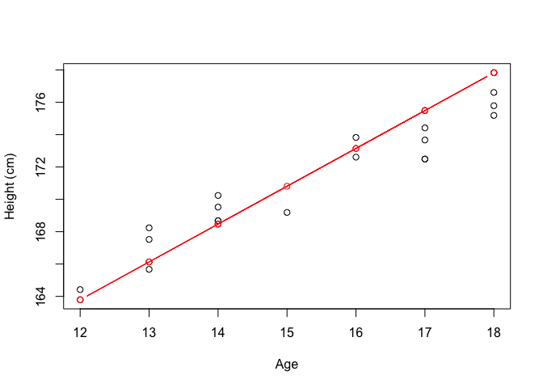

```r
plot(x = data$ages, y = data$heights, xlab = "Age", ylab = "Height (cm)")
par(new = TRUE)
plot(x = data$ages, y = y_hat, type = "b" , col = "red", axes = FALSE, xlab = "", ylab = "")
```

```r
summary(lm(heights ~ ages, data))
```

```
##
## Call:
## lm(formula = heights ~ ages, data = data)
##
## Residuals:
##      Min       1Q   Median       3Q      Max
## -1.66934 -0.89120  0.01832  0.73273  1.83811
##
## Coefficients:
##             Estimate Std. Error t value Pr(>|t|)
## (Intercept) 143.0060     1.8878   75.75  < 2e-16 ***
## ages          1.8326     0.1223   14.99 1.31e-11 ***
## ---
## Signif. codes:  0 '***' 0.001 '**' 0.01 '*' 0.05 '.' 0.1 ' ' 1
##
## Residual standard error: 1.135 on 18 degrees of freedom
## Multiple R-squared:  0.9258, Adjusted R-squared:  0.9217
## F-statistic: 224.7 on 1 and 18 DF,  p-value: 1.306e-11
```

Back to top

# 8 `R Markdown` and `R Sweave`

- Very elegent and powerful tools to use with `Rstudio`.
- Work very well for homework, reports, presentations, etc.
- `R Markdown` is mainly for generating `.html` files though it can also generate `.pdf` files and many more (this file is generated by `R Markdown`).
- `R Sweave` is like $\LaTeX$ but with `R` chunks within. It generates standard `.pdf` files.

# 9 A fun exercise if you would like to try

## 9.1 Recursive functions

Create 3 `N`-element row vectors `p`, `q`, and `r`:
$$\begin{cases}
\mathtt{p}: &\text{prime number sequence},\\
\mathtt{q}: &\text{Fibonacci sequence},\\
\mathtt{r}: &r_n=\lfloor\sqrt{n\pi}\rfloor.
\end{cases}$$
Do NOT compute the terms manually (write functions!).

**Click for answer**

```r
prime_seq <- function(n, i = 1, primes = c()){
  if(length(primes) < n) {
    if (i == 2 || sum(as.numeric(i %% (1:i) == 0)) == 2){
      prime_seq(n = n, i = i + 1, primes = c(primes, i))
    }else{
      prime_seq(n = n, i = i + 1, primes = primes)
    }
  }else{
    return(primes)
  }
}

fibonacci_seq <- function (n){
  fib = c()
  for (i in 1:n){
    if (i == 1){
      fib <- c(fib, 0)
    }else if(i == 2){
      fib <- c(fib, 1)
    }else{
      fib <- c(fib, fib[i - 1] + fib[i - 2])
    }
  }
  return(fib)
}
r_seq <- function(n) return(floor(sqrt((1:n) * pi)))

N <- 5
(p <- prime_seq(n = N))
```

```
## [1]  2  3  5  7 11
```

```r
(q <- fibonacci_seq(n = N))
```

```
## [1] 0 1 1 2 3
```

```r
(r <- r_seq(N))
```

```
## [1] 1 2 3 3 3
```

Also, create matrices:
$$A=\begin{pmatrix}
\mathtt p \\ \mathtt q \\ \mathtt r
\end{pmatrix},
B=\begin{pmatrix}
\mathtt p^\intercal & \mathtt q^\intercal & \mathtt r^\intercal
\end{pmatrix}$$

**Click for answer**

```r
(A <- rbind(p, q, r))
```

```
##   [,1] [,2] [,3] [,4] [,5]
## p    2    3    5    7   11
## q    0    1    1    2    3
## r    1    2    3    3    3
```

```r
(B <- cbind(p, q, r))
```

```
##       p q r
## [1,]  2 0 1
## [2,]  3 1 2
## [3,]  5 1 3
## [4,]  7 2 3
## [5,] 11 3 3
```

Back to top